# Caso práctico python

##### 1. Cargar los dos CSV como datasets.

```python
import numpy as np
import pandas as pd
```

```python
df_15 = pd.read_csv('informe felicidad 2015.csv', sep=',')
df_15
```

|  | Country | Region | Happiness Rank | Happiness Score | Standard Error | Economy (GDP per Capita) | Family | Health (Life Expectancy) | Freedom | Trust (Government Corruption) | Generosity | Dystopia Residual |
| --- | --- | --- | --- | --- | --- | --- | --- | --- | --- | --- | --- | --- |
| 0 | Switzerland | Western Europe | 1 | 7.587 | 0.03411 | 1.39651 | 1.34951 | 0.94143 | 0.66557 | 0.41978 | 0.29678 | 2.51738 |
| 1 | Iceland | Western Europe | 2 | 7.561 | 0.04884 | 1.30232 | 1.40223 | 0.94784 | 0.62877 | 0.14145 | 0.43630 | 2.70201 |
| 2 | Denmark | Western Europe | 3 | 7.527 | 0.03328 | 1.32548 | 1.36058 | 0.87464 | 0.64938 | 0.48357 | 0.34139 | 2.49204 |
| 3 | Norway | Western Europe | 4 | 7.522 | 0.03880 | 1.45900 | 1.33095 | 0.88521 | 0.66973 | 0.36503 | 0.34699 | 2.46531 |
| 4 | Canada | North America | 5 | 7.427 | 0.03553 | 1.32629 | 1.32261 | 0.90563 | 0.63297 | 0.32957 | 0.45811 | 2.45176 |
| ... | ... | ... | ... | ... | ... | ... | ... | ... | ... | ... | ... | ... |
| 153 | Rwanda | Sub-Saharan Africa | 154 | 3.465 | 0.03464 | 0.22208 | 0.77370 | 0.42864 | 0.59201 | 0.55191 | 0.22628 | 0.67042 |
| 154 | Benin | Sub-Saharan Africa | 155 | 3.340 | 0.03656 | 0.28665 | 0.35386 | 0.31910 | 0.48450 | 0.08010 | 0.18260 | 1.63328 |
| 155 | Syria | Middle East and Northern Africa | 156 | 3.006 | 0.05015 | 0.66320 | 0.47489 | 0.72193 | 0.15684 | 0.18906 | 0.47179 | 0.32858 |
| 156 | Burundi | Sub-Saharan Africa | 157 | 2.905 | 0.08658 | 0.01530 | 0.41587 | 0.22396 | 0.11850 | 0.10062 | 0.19727 | 1.83302 |
| 157 | Togo | Sub-Saharan Africa | 158 | 2.839 | 0.06727 | 0.20868 | 0.13995 | 0.28443 | 0.36453 | 0.10731 | 0.16681 | 1.56726 |

158 rows × 12 columns

```python
df_16 = pd.read_csv('informe felicidad 2016.csv', sep=',')
df_16
```

|  | Country | Region | Happiness Rank | Happiness Score | Lower Confidence Interval | Upper Confidence Interval | Economy (GDP per Capita) | Family | Health (Life Expectancy) | Freedom | Trust (Government Corruption) | Generosity | Dystopia Residual |
| --- | --- | --- | --- | --- | --- | --- | --- | --- | --- | --- | --- | --- | --- |
| 0 | Denmark | Western Europe | 1 | 7.526 | 7.460 | 7.592 | 1.44178 | 1.16374 | 0.79504 | 0.57941 | 0.44453 | 0.36171 | 2.73939 |
| 1 | Switzerland | Western Europe | 2 | 7.509 | 7.428 | 7.590 | 1.52733 | 1.14524 | 0.86303 | 0.58557 | 0.41203 | 0.28083 | 2.69463 |
| 2 | Iceland | Western Europe | 3 | 7.501 | 7.333 | 7.669 | 1.42666 | 1.18326 | 0.86733 | 0.56624 | 0.14975 | 0.47678 | 2.83137 |
| 3 | Norway | Western Europe | 4 | 7.498 | 7.421 | 7.575 | 1.57744 | 1.12690 | 0.79579 | 0.59609 | 0.35776 | 0.37895 | 2.66465 |
| 4 | Finland | Western Europe | 5 | 7.413 | 7.351 | 7.475 | 1.40598 | 1.13464 | 0.81091 | 0.57104 | 0.41004 | 0.25492 | 2.82596 |
| ... | ... | ... | ... | ... | ... | ... | ... | ... | ... | ... | ... | ... | ... |
| 152 | Benin | Sub-Saharan Africa | 153 | 3.484 | 3.404 | 3.564 | 0.39499 | 0.10419 | 0.21028 | 0.39747 | 0.06681 | 0.20180 | 2.10812 |
| 153 | Afghanistan | Southern Asia | 154 | 3.360 | 3.288 | 3.432 | 0.38227 | 0.11037 | 0.17344 | 0.16430 | 0.07112 | 0.31268 | 2.14558 |
| 154 | Togo | Sub-Saharan Africa | 155 | 3.303 | 3.192 | 3.414 | 0.28123 | 0.00000 | 0.24811 | 0.34678 | 0.11587 | 0.17517 | 2.13540 |
| 155 | Syria | Middle East and Northern Africa | 156 | 3.069 | 2.936 | 3.202 | 0.74719 | 0.14866 | 0.62994 | 0.06912 | 0.17233 | 0.48397 | 0.81789 |
| 156 | Burundi | Sub-Saharan Africa | 157 | 2.905 | 2.732 | 3.078 | 0.06831 | 0.23442 | 0.15747 | 0.04320 | 0.09419 | 0.20290 | 2.10404 |

157 rows × 13 columns

##### 2. Identifica las columnas de ambos datasets: ¿hay diferencias entre ambos?

```python
[np.sort(df_15.columns), len(df_15.columns)]
```

```
[array(['Country', 'Dystopia Residual', 'Economy (GDP per Capita)',
        'Family', 'Freedom', 'Generosity', 'Happiness Rank',
        'Happiness Score', 'Health (Life Expectancy)', 'Region',
        'Standard Error', 'Trust (Government Corruption)'], dtype=object),
 12]
```

```python
[np.sort(df_16.columns), len(df_16.columns)]
```

```
[array(['Country', 'Dystopia Residual', 'Economy (GDP per Capita)',
        'Family', 'Freedom', 'Generosity', 'Happiness Rank',
        'Happiness Score', 'Health (Life Expectancy)',
        'Lower Confidence Interval', 'Region',
        'Trust (Government Corruption)', 'Upper Confidence Interval'],
       dtype=object),
 13]
```

- En 2015 aparecía la columna 'Standard Error'
- En 2016 aparecían las columnas 'Lower Confidence Interval' y 'Upper Confidence Interval'
- El resto de columnas son iguales

##### 3. Une ambos dataframes, sin importar que los dos compartan las mismas diferencias.

```python
df_ext = pd.concat([df_15,df_16]) #En la nueva versión de Pandas, append no funciona (al menos eso creo)
df_ext
```

|  | Country | Region | Happiness Rank | Happiness Score | Standard Error | Economy (GDP per Capita) | Family | Health (Life Expectancy) | Freedom | Trust (Government Corruption) | Generosity | Dystopia Residual | Lower Confidence Interval | Upper Confidence Interval |
| --- | --- | --- | --- | --- | --- | --- | --- | --- | --- | --- | --- | --- | --- | --- |
| 0 | Switzerland | Western Europe | 1 | 7.587 | 0.03411 | 1.39651 | 1.34951 | 0.94143 | 0.66557 | 0.41978 | 0.29678 | 2.51738 | NaN | NaN |
| 1 | Iceland | Western Europe | 2 | 7.561 | 0.04884 | 1.30232 | 1.40223 | 0.94784 | 0.62877 | 0.14145 | 0.43630 | 2.70201 | NaN | NaN |
| 2 | Denmark | Western Europe | 3 | 7.527 | 0.03328 | 1.32548 | 1.36058 | 0.87464 | 0.64938 | 0.48357 | 0.34139 | 2.49204 | NaN | NaN |
| 3 | Norway | Western Europe | 4 | 7.522 | 0.03880 | 1.45900 | 1.33095 | 0.88521 | 0.66973 | 0.36503 | 0.34699 | 2.46531 | NaN | NaN |
| 4 | Canada | North America | 5 | 7.427 | 0.03553 | 1.32629 | 1.32261 | 0.90563 | 0.63297 | 0.32957 | 0.45811 | 2.45176 | NaN | NaN |
| ... | ... | ... | ... | ... | ... | ... | ... | ... | ... | ... | ... | ... | ... | ... |
| 152 | Benin | Sub-Saharan Africa | 153 | 3.484 | NaN | 0.39499 | 0.10419 | 0.21028 | 0.39747 | 0.06681 | 0.20180 | 2.10812 | 3.404 | 3.564 |
| 153 | Afghanistan | Southern Asia | 154 | 3.360 | NaN | 0.38227 | 0.11037 | 0.17344 | 0.16430 | 0.07112 | 0.31268 | 2.14558 | 3.288 | 3.432 |
| 154 | Togo | Sub-Saharan Africa | 155 | 3.303 | NaN | 0.28123 | 0.00000 | 0.24811 | 0.34678 | 0.11587 | 0.17517 | 2.13540 | 3.192 | 3.414 |
| 155 | Syria | Middle East and Northern Africa | 156 | 3.069 | NaN | 0.74719 | 0.14866 | 0.62994 | 0.06912 | 0.17233 | 0.48397 | 0.81789 | 2.936 | 3.202 |
| 156 | Burundi | Sub-Saharan Africa | 157 | 2.905 | NaN | 0.06831 | 0.23442 | 0.15747 | 0.04320 | 0.09419 | 0.20290 | 2.10404 | 2.732 | 3.078 |

315 rows × 14 columns

##### 4. Revisa el número de nulos que hay por cada columna, así como su porcentaje.

```python
df_ext.isna().sum()
```

```
Country                            0
Region                             0
Happiness Rank                     0
Happiness Score                    0
Standard Error                   157
Economy (GDP per Capita)           0
Family                             0
Health (Life Expectancy)           0
Freedom                            0
Trust (Government Corruption)      0
Generosity                         0
Dystopia Residual                  0
Lower Confidence Interval        158
Upper Confidence Interval        158
dtype: int64
```

```python
df_ext.isna().sum() / len(df_ext) * 100
```

```
Country                           0.00000
Region                            0.00000
Happiness Rank                    0.00000
Happiness Score                   0.00000
Standard Error                   49.84127
Economy (GDP per Capita)          0.00000
Family                            0.00000
Health (Life Expectancy)          0.00000
Freedom                           0.00000
Trust (Government Corruption)     0.00000
Generosity                        0.00000
Dystopia Residual                 0.00000
Lower Confidence Interval        50.15873
Upper Confidence Interval        50.15873
dtype: float64
```

##### 5. Cambia los valores nulos de las columnas "Lower Confidence Interval" y "Upper Confidence Interval" por un número aleatorio entre el valor mínimo y máximo de la misma columna (un único número, no es necesario uno diferente para cada fila con valor nulo).

```python
min_upp = np.min(df_ext['Upper Confidence Interval'])
max_upp = np.max(df_ext['Upper Confidence Interval'])

min_low = np.min(df_ext['Lower Confidence Interval'])
max_low = np.max(df_ext['Lower Confidence Interval'])

[min_upp, max_upp, min_low, max_low]
```

```
[3.078, 7.669, 2.732, 7.46]
```

```python
df_ext['Lower Confidence Interval'].fillna(np.random.uniform(low=min_low, high=max_low), inplace=True)
```

```python
df_ext['Upper Confidence Interval'].fillna(np.random.uniform(low=min_upp, high=max_upp), inplace=True)
```

```python
df_ext
```

|  | Country | Region | Happiness Rank | Happiness Score | Standard Error | Economy (GDP per Capita) | Family | Health (Life Expectancy) | Freedom | Trust (Government Corruption) | Generosity | Dystopia Residual | Lower Confidence Interval | Upper Confidence Interval |
| --- | --- | --- | --- | --- | --- | --- | --- | --- | --- | --- | --- | --- | --- | --- |
| 0 | Switzerland | Western Europe | 1 | 7.587 | 0.03411 | 1.39651 | 1.34951 | 0.94143 | 0.66557 | 0.41978 | 0.29678 | 2.51738 | 6.325207 | 3.918143 |
| 1 | Iceland | Western Europe | 2 | 7.561 | 0.04884 | 1.30232 | 1.40223 | 0.94784 | 0.62877 | 0.14145 | 0.43630 | 2.70201 | 6.325207 | 3.918143 |
| 2 | Denmark | Western Europe | 3 | 7.527 | 0.03328 | 1.32548 | 1.36058 | 0.87464 | 0.64938 | 0.48357 | 0.34139 | 2.49204 | 6.325207 | 3.918143 |
| 3 | Norway | Western Europe | 4 | 7.522 | 0.03880 | 1.45900 | 1.33095 | 0.88521 | 0.66973 | 0.36503 | 0.34699 | 2.46531 | 6.325207 | 3.918143 |
| 4 | Canada | North America | 5 | 7.427 | 0.03553 | 1.32629 | 1.32261 | 0.90563 | 0.63297 | 0.32957 | 0.45811 | 2.45176 | 6.325207 | 3.918143 |
| ... | ... | ... | ... | ... | ... | ... | ... | ... | ... | ... | ... | ... | ... | ... |
| 152 | Benin | Sub-Saharan Africa | 153 | 3.484 | NaN | 0.39499 | 0.10419 | 0.21028 | 0.39747 | 0.06681 | 0.20180 | 2.10812 | 3.404000 | 3.564000 |
| 153 | Afghanistan | Southern Asia | 154 | 3.360 | NaN | 0.38227 | 0.11037 | 0.17344 | 0.16430 | 0.07112 | 0.31268 | 2.14558 | 3.288000 | 3.432000 |
| 154 | Togo | Sub-Saharan Africa | 155 | 3.303 | NaN | 0.28123 | 0.00000 | 0.24811 | 0.34678 | 0.11587 | 0.17517 | 2.13540 | 3.192000 | 3.414000 |
| 155 | Syria | Middle East and Northern Africa | 156 | 3.069 | NaN | 0.74719 | 0.14866 | 0.62994 | 0.06912 | 0.17233 | 0.48397 | 0.81789 | 2.936000 | 3.202000 |
| 156 | Burundi | Sub-Saharan Africa | 157 | 2.905 | NaN | 0.06831 | 0.23442 | 0.15747 | 0.04320 | 0.09419 | 0.20290 | 2.10404 | 2.732000 | 3.078000 |

315 rows × 14 columns

##### 6. Cambia los valores nulos de la columna "Standard Error" por su media al cuadrado.

```python
std_mean_squared = df_ext['Standard Error'].mean()**2
std_mean_squared
```

```
0.002292948979494472
```

```python
df_ext['Standard Error'].fillna(std_mean_squared, inplace=True)
```

```python
df_ext
```

|  | Country | Region | Happiness Rank | Happiness Score | Standard Error | Economy (GDP per Capita) | Family | Health (Life Expectancy) | Freedom | Trust (Government Corruption) | Generosity | Dystopia Residual | Lower Confidence Interval | Upper Confidence Interval |
| --- | --- | --- | --- | --- | --- | --- | --- | --- | --- | --- | --- | --- | --- | --- |
| 0 | Switzerland | Western Europe | 1 | 7.587 | 0.034110 | 1.39651 | 1.34951 | 0.94143 | 0.66557 | 0.41978 | 0.29678 | 2.51738 | 6.325207 | 3.918143 |
| 1 | Iceland | Western Europe | 2 | 7.561 | 0.048840 | 1.30232 | 1.40223 | 0.94784 | 0.62877 | 0.14145 | 0.43630 | 2.70201 | 6.325207 | 3.918143 |
| 2 | Denmark | Western Europe | 3 | 7.527 | 0.033280 | 1.32548 | 1.36058 | 0.87464 | 0.64938 | 0.48357 | 0.34139 | 2.49204 | 6.325207 | 3.918143 |
| 3 | Norway | Western Europe | 4 | 7.522 | 0.038800 | 1.45900 | 1.33095 | 0.88521 | 0.66973 | 0.36503 | 0.34699 | 2.46531 | 6.325207 | 3.918143 |
| 4 | Canada | North America | 5 | 7.427 | 0.035530 | 1.32629 | 1.32261 | 0.90563 | 0.63297 | 0.32957 | 0.45811 | 2.45176 | 6.325207 | 3.918143 |
| ... | ... | ... | ... | ... | ... | ... | ... | ... | ... | ... | ... | ... | ... | ... |
| 152 | Benin | Sub-Saharan Africa | 153 | 3.484 | 0.002293 | 0.39499 | 0.10419 | 0.21028 | 0.39747 | 0.06681 | 0.20180 | 2.10812 | 3.404000 | 3.564000 |
| 153 | Afghanistan | Southern Asia | 154 | 3.360 | 0.002293 | 0.38227 | 0.11037 | 0.17344 | 0.16430 | 0.07112 | 0.31268 | 2.14558 | 3.288000 | 3.432000 |
| 154 | Togo | Sub-Saharan Africa | 155 | 3.303 | 0.002293 | 0.28123 | 0.00000 | 0.24811 | 0.34678 | 0.11587 | 0.17517 | 2.13540 | 3.192000 | 3.414000 |
| 155 | Syria | Middle East and Northern Africa | 156 | 3.069 | 0.002293 | 0.74719 | 0.14866 | 0.62994 | 0.06912 | 0.17233 | 0.48397 | 0.81789 | 2.936000 | 3.202000 |
| 156 | Burundi | Sub-Saharan Africa | 157 | 2.905 | 0.002293 | 0.06831 | 0.23442 | 0.15747 | 0.04320 | 0.09419 | 0.20290 | 2.10404 | 2.732000 | 3.078000 |

315 rows × 14 columns

```python
df_ext.isna().sum() # Ya no hay valores nulos
```

```
Country                          0
Region                           0
Happiness Rank                   0
Happiness Score                  0
Standard Error                   0
Economy (GDP per Capita)         0
Family                           0
Health (Life Expectancy)         0
Freedom                          0
Trust (Government Corruption)    0
Generosity                       0
Dystopia Residual                0
Lower Confidence Interval        0
Upper Confidence Interval        0
dtype: int64
```

##### 7. Obtén un resumen estadístico del dataframe sin valores nulos.

```python
df_ext.describe()
```

|  | Happiness Rank | Happiness Score | Standard Error | Economy (GDP per Capita) | Family | Health (Life Expectancy) | Freedom | Trust (Government Corruption) | Generosity | Dystopia Residual | Lower Confidence Interval | Upper Confidence Interval |
| --- | --- | --- | --- | --- | --- | --- | --- | --- | --- | --- | --- | --- |
| count | 315.000000 | 315.000000 | 315.000000 | 315.000000 | 315.000000 | 315.000000 | 315.000000 | 315.000000 | 315.000000 | 315.000000 | 315.000000 | 315.000000 |
| mean | 79.238095 | 5.378949 | 0.025161 | 0.899837 | 0.892647 | 0.594054 | 0.399896 | 0.140532 | 0.239957 | 2.212032 | 5.805456 | 4.697576 |
| std | 45.538922 | 1.141531 | 0.025851 | 0.410780 | 0.286718 | 0.240790 | 0.150684 | 0.115490 | 0.130077 | 0.558728 | 0.963084 | 1.120281 |
| min | 1.000000 | 2.839000 | 0.002293 | 0.000000 | 0.000000 | 0.000000 | 0.000000 | 0.000000 | 0.000000 | 0.328580 | 2.732000 | 3.078000 |
| 25% | 40.000000 | 4.510000 | 0.002293 | 0.594900 | 0.739880 | 0.419645 | 0.295890 | 0.061315 | 0.151430 | 1.884135 | 5.266000 | 3.918143 |
| 50% | 79.000000 | 5.286000 | 0.018480 | 0.973060 | 0.937930 | 0.640450 | 0.413190 | 0.106130 | 0.218540 | 2.211260 | 6.325207 | 3.918143 |
| 75% | 118.500000 | 6.269000 | 0.043940 | 1.229000 | 1.087360 | 0.787640 | 0.516730 | 0.178610 | 0.311450 | 2.563470 | 6.325207 | 5.408500 |
| max | 158.000000 | 7.587000 | 0.136930 | 1.824270 | 1.402230 | 1.025250 | 0.669730 | 0.551910 | 0.819710 | 3.837720 | 7.460000 | 7.669000 |

##### 8. Muestra de forma gráfica la relación entre la familia y la salud.

```python
from plotnine import *
```

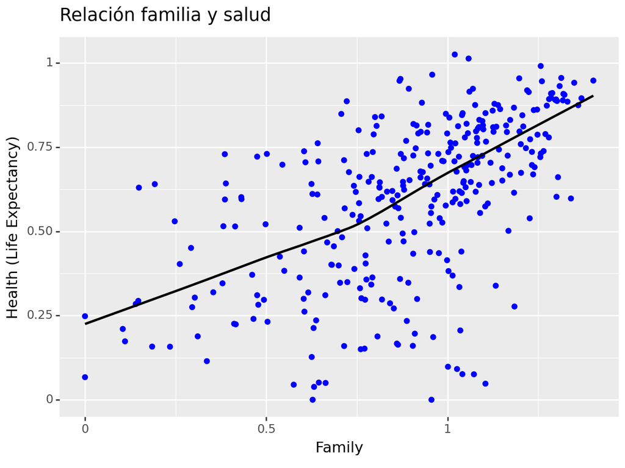

```
<Figure Size: (640 x 480)>
```

```python
(
ggplot(df_ext) +
geom_point(aes(x='Family', y = 'Health (Life Expectancy)'), color='blue',
shape='o')
+ geom_smooth(
aes(x='Family', y = 'Health (Life Expectancy)')
)
+ labs(title='Relación familia y salud',
x = 'Family',
y = 'Health (Life Expectancy)')
)
```

##### 9. Muestra de forma gráfica la relación entre la puntuación de felicidad y la confianza (corrupción del gobierno).

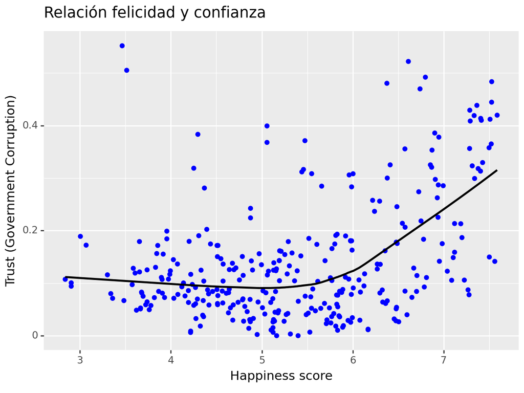

```
<Figure Size: (640 x 480)>
```

```python
(
ggplot(df_ext) +
geom_point(aes(x='Happiness Score', y = 'Trust (Government Corruption)'), color='blue',
shape='o')
+ geom_smooth(
aes(x='Happiness Score', y = 'Trust (Government Corruption)')
)
+ labs(title='Relación felicidad y confianza',
x = 'Happiness score',
y = 'Trust (Government Corruption)')
)
```

##### 10. Muestra la matriz de correlación del daframe.

```python
df_ext.corr(numeric_only=True) # No consideramos columnas con strings como el nombre del país
```

|  | Happiness Rank | Happiness Score | Standard Error | Economy (GDP per Capita) | Family | Health (Life Expectancy) | Freedom | Trust (Government Corruption) | Generosity | Dystopia Residual | Lower Confidence Interval | Upper Confidence Interval |
| --- | --- | --- | --- | --- | --- | --- | --- | --- | --- | --- | --- | --- |
| Happiness Rank | 1.000000 | -0.993905 | 0.057798 | -0.783247 | -0.686502 | -0.741182 | -0.545570 | -0.378864 | -0.152613 | -0.522146 | -0.585223 | -0.504889 |
| Happiness Score | -0.993905 | 1.000000 | -0.061461 | 0.779171 | 0.693547 | 0.734491 | 0.556414 | 0.397989 | 0.168272 | 0.526343 | 0.590462 | 0.505781 |
| Standard Error | 0.057798 | -0.061461 | 1.000000 | -0.186844 | 0.266522 | 0.027844 | 0.126096 | -0.039259 | -0.046720 | -0.151971 | 0.478917 | -0.617421 |
| Economy (GDP per Capita) | -0.783247 | 0.779171 | -0.186844 | 1.000000 | 0.566283 | 0.789103 | 0.331127 | 0.294856 | -0.015402 | 0.079411 | 0.399103 | 0.491313 |
| Family | -0.686502 | 0.693547 | 0.266522 | 0.566283 | 1.000000 | 0.569937 | 0.476671 | 0.205060 | 0.075987 | 0.053264 | 0.595484 | 0.104082 |
| Health (Life Expectancy) | -0.741182 | 0.734491 | 0.027844 | 0.789103 | 0.569937 | 1.000000 | 0.369799 | 0.249773 | 0.088002 | 0.025248 | 0.515805 | 0.259591 |
| Freedom | -0.545570 | 0.556414 | 0.126096 | 0.331127 | 0.476671 | 0.369799 | 1.000000 | 0.492875 | 0.356615 | 0.034829 | 0.428018 | 0.141691 |
| Trust (Government Corruption) | -0.378864 | 0.397989 | -0.039259 | 0.294856 | 0.205060 | 0.249773 | 0.492875 | 1.000000 | 0.289499 | -0.023504 | 0.244148 | 0.175661 |
| Generosity | -0.152613 | 0.168272 | -0.046720 | -0.015402 | 0.075987 | 0.088002 | 0.356615 | 0.289499 | 1.000000 | -0.110632 | 0.085087 | 0.094957 |
| Dystopia Residual | -0.522146 | 0.526343 | -0.151971 | 0.079411 | 0.053264 | 0.025248 | 0.034829 | -0.023504 | -0.110632 | 1.000000 | 0.199415 | 0.410242 |
| Lower Confidence Interval | -0.585223 | 0.590462 | 0.478917 | 0.399103 | 0.595484 | 0.515805 | 0.428018 | 0.244148 | 0.085087 | 0.199415 | 1.000000 | 0.220476 |
| Upper Confidence Interval | -0.504889 | 0.505781 | -0.617421 | 0.491313 | 0.104082 | 0.259591 | 0.141691 | 0.175661 | 0.094957 | 0.410242 | 0.220476 | 1.000000 |

##### 11. Tras unir los dataframes, los países aparecerán más de una vez. Muestra agrupado el dataframe por país con el valor máximo de felicidad, sin importar el año.

```python
fil = df_ext.groupby(['Country'])[['Country', 'Happiness Score']].max()
fil
fil2 = fil['Country'] + '-' + fil['Happiness Score'].astype('str')
fil2 # Creo una columna filtro para poder identificar las filas con la felicidad más alta
```

```
Country
Afghanistan    Afghanistan-3.575
Albania            Albania-4.959
Algeria            Algeria-6.355
Angola              Angola-4.033
Argentina         Argentina-6.65
                     ...
Venezuela         Venezuela-6.81
Vietnam             Vietnam-5.36
Yemen                Yemen-4.077
Zambia              Zambia-5.129
Zimbabwe           Zimbabwe-4.61
Length: 164, dtype: object
```

```python
df_ext['Filter'] = df_ext['Country'] + '-' + df_ext['Happiness Score'].astype('str')
df_ext # Creo la columna en el data frame
```

|  | Country | Region | Happiness Rank | Happiness Score | Standard Error | Economy (GDP per Capita) | Family | Health (Life Expectancy) | Freedom | Trust (Government Corruption) | Generosity | Dystopia Residual | Lower Confidence Interval | Upper Confidence Interval | Filter |
| --- | --- | --- | --- | --- | --- | --- | --- | --- | --- | --- | --- | --- | --- | --- | --- |
| 0 | Switzerland | Western Europe | 1 | 7.587 | 0.034110 | 1.39651 | 1.34951 | 0.94143 | 0.66557 | 0.41978 | 0.29678 | 2.51738 | 6.325207 | 3.918143 | Switzerland-7.587 |
| 1 | Iceland | Western Europe | 2 | 7.561 | 0.048840 | 1.30232 | 1.40223 | 0.94784 | 0.62877 | 0.14145 | 0.43630 | 2.70201 | 6.325207 | 3.918143 | Iceland-7.561 |
| 2 | Denmark | Western Europe | 3 | 7.527 | 0.033280 | 1.32548 | 1.36058 | 0.87464 | 0.64938 | 0.48357 | 0.34139 | 2.49204 | 6.325207 | 3.918143 | Denmark-7.527 |
| 3 | Norway | Western Europe | 4 | 7.522 | 0.038800 | 1.45900 | 1.33095 | 0.88521 | 0.66973 | 0.36503 | 0.34699 | 2.46531 | 6.325207 | 3.918143 | Norway-7.522 |
| 4 | Canada | North America | 5 | 7.427 | 0.035530 | 1.32629 | 1.32261 | 0.90563 | 0.63297 | 0.32957 | 0.45811 | 2.45176 | 6.325207 | 3.918143 | Canada-7.427 |
| ... | ... | ... | ... | ... | ... | ... | ... | ... | ... | ... | ... | ... | ... | ... | ... |
| 152 | Benin | Sub-Saharan Africa | 153 | 3.484 | 0.002293 | 0.39499 | 0.10419 | 0.21028 | 0.39747 | 0.06681 | 0.20180 | 2.10812 | 3.404000 | 3.564000 | Benin-3.484 |
| 153 | Afghanistan | Southern Asia | 154 | 3.360 | 0.002293 | 0.38227 | 0.11037 | 0.17344 | 0.16430 | 0.07112 | 0.31268 | 2.14558 | 3.288000 | 3.432000 | Afghanistan-3.36 |
| 154 | Togo | Sub-Saharan Africa | 155 | 3.303 | 0.002293 | 0.28123 | 0.00000 | 0.24811 | 0.34678 | 0.11587 | 0.17517 | 2.13540 | 3.192000 | 3.414000 | Togo-3.303 |
| 155 | Syria | Middle East and Northern Africa | 156 | 3.069 | 0.002293 | 0.74719 | 0.14866 | 0.62994 | 0.06912 | 0.17233 | 0.48397 | 0.81789 | 2.936000 | 3.202000 | Syria-3.069 |
| 156 | Burundi | Sub-Saharan Africa | 157 | 2.905 | 0.002293 | 0.06831 | 0.23442 | 0.15747 | 0.04320 | 0.09419 | 0.20290 | 2.10404 | 2.732000 | 3.078000 | Burundi-2.905 |

315 rows × 15 columns

```python
df_ext_fil = df_ext[df_ext['Filter'].isin(fil2)]
df_ext_fil # Aplico el filtro
```

|  | Country | Region | Happiness Rank | Happiness Score | Standard Error | Economy (GDP per Capita) | Family | Health (Life Expectancy) | Freedom | Trust (Government Corruption) | Generosity | Dystopia Residual | Lower Confidence Interval | Upper Confidence Interval | Filter |
| --- | --- | --- | --- | --- | --- | --- | --- | --- | --- | --- | --- | --- | --- | --- | --- |
| 0 | Switzerland | Western Europe | 1 | 7.587 | 0.034110 | 1.39651 | 1.34951 | 0.94143 | 0.66557 | 0.41978 | 0.29678 | 2.51738 | 6.325207 | 3.918143 | Switzerland-7.587 |
| 1 | Iceland | Western Europe | 2 | 7.561 | 0.048840 | 1.30232 | 1.40223 | 0.94784 | 0.62877 | 0.14145 | 0.43630 | 2.70201 | 6.325207 | 3.918143 | Iceland-7.561 |
| 2 | Denmark | Western Europe | 3 | 7.527 | 0.033280 | 1.32548 | 1.36058 | 0.87464 | 0.64938 | 0.48357 | 0.34139 | 2.49204 | 6.325207 | 3.918143 | Denmark-7.527 |
| 3 | Norway | Western Europe | 4 | 7.522 | 0.038800 | 1.45900 | 1.33095 | 0.88521 | 0.66973 | 0.36503 | 0.34699 | 2.46531 | 6.325207 | 3.918143 | Norway-7.522 |
| 4 | Canada | North America | 5 | 7.427 | 0.035530 | 1.32629 | 1.32261 | 0.90563 | 0.63297 | 0.32957 | 0.45811 | 2.45176 | 6.325207 | 3.918143 | Canada-7.427 |
| ... | ... | ... | ... | ... | ... | ... | ... | ... | ... | ... | ... | ... | ... | ... | ... |
| 151 | Rwanda | Sub-Saharan Africa | 152 | 3.515 | 0.002293 | 0.32846 | 0.61586 | 0.31865 | 0.54320 | 0.50521 | 0.23552 | 0.96819 | 3.444000 | 3.586000 | Rwanda-3.515 |
| 152 | Benin | Sub-Saharan Africa | 153 | 3.484 | 0.002293 | 0.39499 | 0.10419 | 0.21028 | 0.39747 | 0.06681 | 0.20180 | 2.10812 | 3.404000 | 3.564000 | Benin-3.484 |
| 154 | Togo | Sub-Saharan Africa | 155 | 3.303 | 0.002293 | 0.28123 | 0.00000 | 0.24811 | 0.34678 | 0.11587 | 0.17517 | 2.13540 | 3.192000 | 3.414000 | Togo-3.303 |
| 155 | Syria | Middle East and Northern Africa | 156 | 3.069 | 0.002293 | 0.74719 | 0.14866 | 0.62994 | 0.06912 | 0.17233 | 0.48397 | 0.81789 | 2.936000 | 3.202000 | Syria-3.069 |
| 156 | Burundi | Sub-Saharan Africa | 157 | 2.905 | 0.002293 | 0.06831 | 0.23442 | 0.15747 | 0.04320 | 0.09419 | 0.20290 | 2.10404 | 2.732000 | 3.078000 | Burundi-2.905 |

169 rows × 15 columns

```python
len(df_ext_fil['Filter'].unique()) # Me doy cuenta que hay paises con el mismo valor de felicidad en ambos años
                                   # (164 valores únicos vs 169 filas del dataframe)
```

```
164
```

```python
df_ext_fil = df_ext_fil.drop_duplicates(subset=['Filter'])
df_ext_fil # Elimino estos países (al ser igual la felicidad pues elimino uno cualquiera)
```

|  | Country | Region | Happiness Rank | Happiness Score | Standard Error | Economy (GDP per Capita) | Family | Health (Life Expectancy) | Freedom | Trust (Government Corruption) | Generosity | Dystopia Residual | Lower Confidence Interval | Upper Confidence Interval | Filter |
| --- | --- | --- | --- | --- | --- | --- | --- | --- | --- | --- | --- | --- | --- | --- | --- |
| 0 | Switzerland | Western Europe | 1 | 7.587 | 0.034110 | 1.39651 | 1.34951 | 0.94143 | 0.66557 | 0.41978 | 0.29678 | 2.51738 | 6.325207 | 3.918143 | Switzerland-7.587 |
| 1 | Iceland | Western Europe | 2 | 7.561 | 0.048840 | 1.30232 | 1.40223 | 0.94784 | 0.62877 | 0.14145 | 0.43630 | 2.70201 | 6.325207 | 3.918143 | Iceland-7.561 |
| 2 | Denmark | Western Europe | 3 | 7.527 | 0.033280 | 1.32548 | 1.36058 | 0.87464 | 0.64938 | 0.48357 | 0.34139 | 2.49204 | 6.325207 | 3.918143 | Denmark-7.527 |
| 3 | Norway | Western Europe | 4 | 7.522 | 0.038800 | 1.45900 | 1.33095 | 0.88521 | 0.66973 | 0.36503 | 0.34699 | 2.46531 | 6.325207 | 3.918143 | Norway-7.522 |
| 4 | Canada | North America | 5 | 7.427 | 0.035530 | 1.32629 | 1.32261 | 0.90563 | 0.63297 | 0.32957 | 0.45811 | 2.45176 | 6.325207 | 3.918143 | Canada-7.427 |
| ... | ... | ... | ... | ... | ... | ... | ... | ... | ... | ... | ... | ... | ... | ... | ... |
| 147 | Madagascar | Sub-Saharan Africa | 148 | 3.695 | 0.002293 | 0.27954 | 0.46115 | 0.37109 | 0.13684 | 0.07506 | 0.22040 | 2.15075 | 3.621000 | 3.769000 | Madagascar-3.695 |
| 151 | Rwanda | Sub-Saharan Africa | 152 | 3.515 | 0.002293 | 0.32846 | 0.61586 | 0.31865 | 0.54320 | 0.50521 | 0.23552 | 0.96819 | 3.444000 | 3.586000 | Rwanda-3.515 |
| 152 | Benin | Sub-Saharan Africa | 153 | 3.484 | 0.002293 | 0.39499 | 0.10419 | 0.21028 | 0.39747 | 0.06681 | 0.20180 | 2.10812 | 3.404000 | 3.564000 | Benin-3.484 |
| 154 | Togo | Sub-Saharan Africa | 155 | 3.303 | 0.002293 | 0.28123 | 0.00000 | 0.24811 | 0.34678 | 0.11587 | 0.17517 | 2.13540 | 3.192000 | 3.414000 | Togo-3.303 |
| 155 | Syria | Middle East and Northern Africa | 156 | 3.069 | 0.002293 | 0.74719 | 0.14866 | 0.62994 | 0.06912 | 0.17233 | 0.48397 | 0.81789 | 2.936000 | 3.202000 | Syria-3.069 |

164 rows × 15 columns

```python
df_ext_fil = df_ext_fil.drop('Filter', axis=1)
df_ext_fil # Por último dejo el dataframe como estaba, sin la columna filtro
```

|  | Country | Region | Happiness Rank | Happiness Score | Standard Error | Economy (GDP per Capita) | Family | Health (Life Expectancy) | Freedom | Trust (Government Corruption) | Generosity | Dystopia Residual | Lower Confidence Interval | Upper Confidence Interval |
| --- | --- | --- | --- | --- | --- | --- | --- | --- | --- | --- | --- | --- | --- | --- |
| 0 | Switzerland | Western Europe | 1 | 7.587 | 0.034110 | 1.39651 | 1.34951 | 0.94143 | 0.66557 | 0.41978 | 0.29678 | 2.51738 | 6.325207 | 3.918143 |
| 1 | Iceland | Western Europe | 2 | 7.561 | 0.048840 | 1.30232 | 1.40223 | 0.94784 | 0.62877 | 0.14145 | 0.43630 | 2.70201 | 6.325207 | 3.918143 |
| 2 | Denmark | Western Europe | 3 | 7.527 | 0.033280 | 1.32548 | 1.36058 | 0.87464 | 0.64938 | 0.48357 | 0.34139 | 2.49204 | 6.325207 | 3.918143 |
| 3 | Norway | Western Europe | 4 | 7.522 | 0.038800 | 1.45900 | 1.33095 | 0.88521 | 0.66973 | 0.36503 | 0.34699 | 2.46531 | 6.325207 | 3.918143 |
| 4 | Canada | North America | 5 | 7.427 | 0.035530 | 1.32629 | 1.32261 | 0.90563 | 0.63297 | 0.32957 | 0.45811 | 2.45176 | 6.325207 | 3.918143 |
| ... | ... | ... | ... | ... | ... | ... | ... | ... | ... | ... | ... | ... | ... | ... |
| 147 | Madagascar | Sub-Saharan Africa | 148 | 3.695 | 0.002293 | 0.27954 | 0.46115 | 0.37109 | 0.13684 | 0.07506 | 0.22040 | 2.15075 | 3.621000 | 3.769000 |
| 151 | Rwanda | Sub-Saharan Africa | 152 | 3.515 | 0.002293 | 0.32846 | 0.61586 | 0.31865 | 0.54320 | 0.50521 | 0.23552 | 0.96819 | 3.444000 | 3.586000 |
| 152 | Benin | Sub-Saharan Africa | 153 | 3.484 | 0.002293 | 0.39499 | 0.10419 | 0.21028 | 0.39747 | 0.06681 | 0.20180 | 2.10812 | 3.404000 | 3.564000 |
| 154 | Togo | Sub-Saharan Africa | 155 | 3.303 | 0.002293 | 0.28123 | 0.00000 | 0.24811 | 0.34678 | 0.11587 | 0.17517 | 2.13540 | 3.192000 | 3.414000 |
| 155 | Syria | Middle East and Northern Africa | 156 | 3.069 | 0.002293 | 0.74719 | 0.14866 | 0.62994 | 0.06912 | 0.17233 | 0.48397 | 0.81789 | 2.936000 | 3.202000 |

164 rows × 14 columns

##### 12. ¿Tiene relación la felicidad con la generosidad? Muéstralo gráficamente a través de la puntuación de libertad.

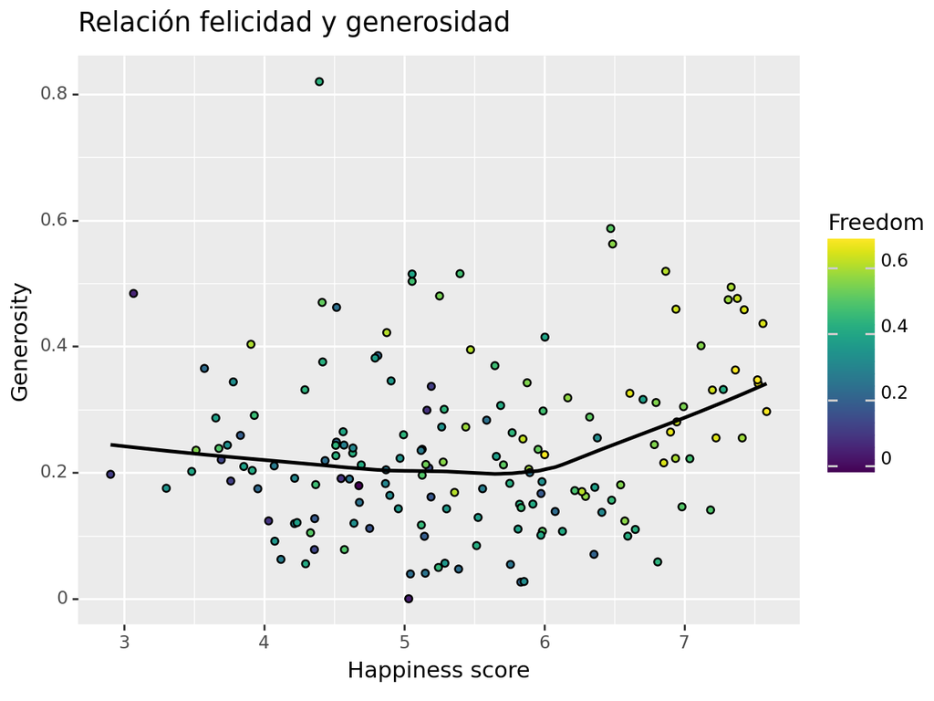

```
<Figure Size: (640 x 480)>
```

```python
(
ggplot(df_ext_fil) +
geom_point(aes(x='Happiness Score', y = 'Generosity', fill = 'Freedom'),
shape='o')
+ geom_smooth(
aes(x='Happiness Score', y = 'Generosity')
)
+ labs(title='Relación felicidad y generosidad',
x = 'Happiness score',
y = 'Generosity')
)
```

Curiosamente parece que solo con valores altos de felicidad se aprecia una mejoría cuando la generosidad aumenta

##### 13. Muestra la distribución del grado de distopía en función de la región.

```python
df_dys = df_ext_fil[['Region', 'Dystopia Residual']]
df_dys
```

|  | Region | Dystopia Residual |
| --- | --- | --- |
| 0 | Western Europe | 2.51738 |
| 1 | Western Europe | 2.70201 |
| 2 | Western Europe | 2.49204 |
| 3 | Western Europe | 2.46531 |
| 4 | North America | 2.45176 |
| ... | ... | ... |
| 147 | Sub-Saharan Africa | 2.15075 |
| 151 | Sub-Saharan Africa | 0.96819 |
| 152 | Sub-Saharan Africa | 2.10812 |
| 154 | Sub-Saharan Africa | 2.13540 |
| 155 | Middle East and Northern Africa | 0.81789 |

164 rows × 2 columns

```python
import matplotlib.pyplot as plt
```

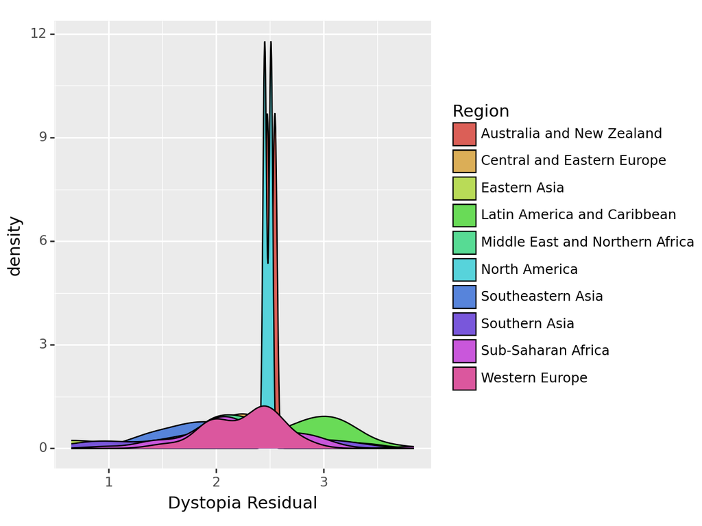

```
<Figure Size: (640 x 480)>
```

```python
# Distribución sobre dataframe con países sin repetir

(
ggplot(df_ext_fil)+
    geom_density(aes(x= "Dystopia Residual", fill = "Region"))

)
```

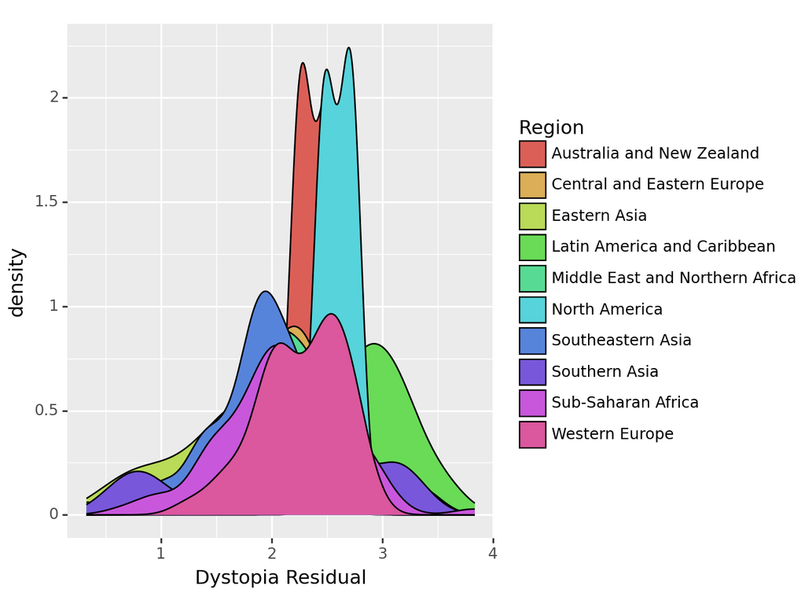

```
<Figure Size: (640 x 480)>
```

```python
# Distribución sobre dataframe con paises repetidos

(
ggplot(df_ext)+
    geom_density(aes(x= "Dystopia Residual", fill = "Region"))

)
```